# Week 1 Lecture 2: Old Faithful Notebook

Bikramjit Das

Fall 2025

# 1 Data sets

## 1.1 List datasets available in R

```r
data()
```

## 1.2 Load the Old Faithful Geyser dataset

```r
data(faithful)
ls()
```

```
## [1] "faithful"
```

```r
?faithful
```

```
## starting httpd help server ... done
```

Display (compactly) the internal structure of the R object - here it is a dataframe with 272 observations and 2 variables

```r
str(faithful)
```

```
## 'data.frame':    272 obs. of  2 variables:
##  $ eruptions: num  3.6 1.8 3.33 2.28 4.53 ...
##  $ waiting  : num  79 54 74 62 85 55 88 85 51 85 ...
```

The **Old Faithful Geyser** is a hot spring that occasionally becomes unstable and erupts hot water and steam into the air. The Old Faithful Geyser is at Yellowstone Park, Wyoming.

# 2 Visualisation

## 2.1 Scatter plot

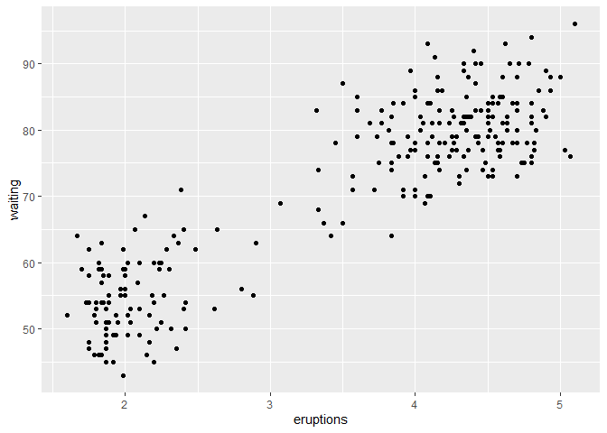

```r
library(ggplot2)
qplot(eruptions,waiting,data=faithful)
```

## 2.2 Histogram

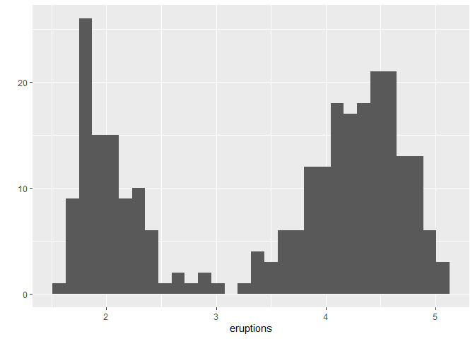

```r
qplot(eruptions,data=faithful)
```

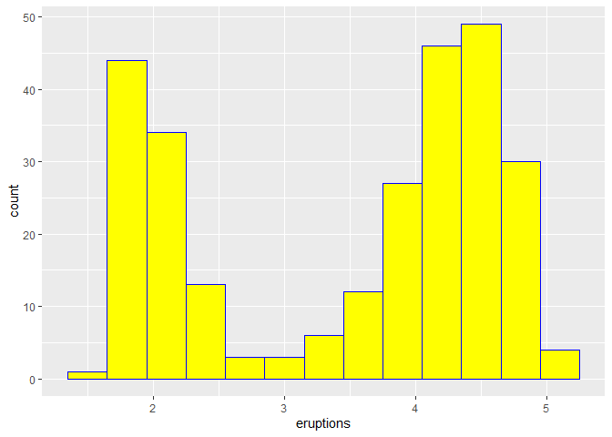

```r
a1<-ggplot(faithful,aes(eruptions))
a1+geom_histogram(binwidth = .3,color="blue",fill="yellow")
```

## 2.3 Time series plot*

```r
index=1:length(faithful$eruptions)
index
```

[output not shown]

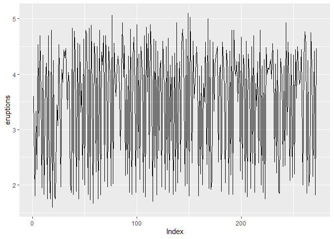

```r
qplot(index,eruptions,data=faithful,geom="line",xlab="Index")
```

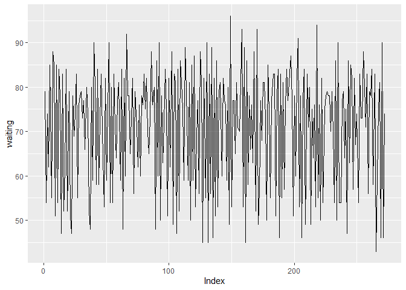

```r
qplot(index,waiting,data=faithful,geom="line",xlab="Index")
```

```r
# ggplot(faithful)+geom_line(aes(x=1:length(eruptions),y=eruptions))+xlab("Index")
# ggplot(faithful)+geom_line(aes(x=1:length(waiting),y=waiting))+xlab("Index")
```

## 2.4 Empirical cdf plot for eruptions*

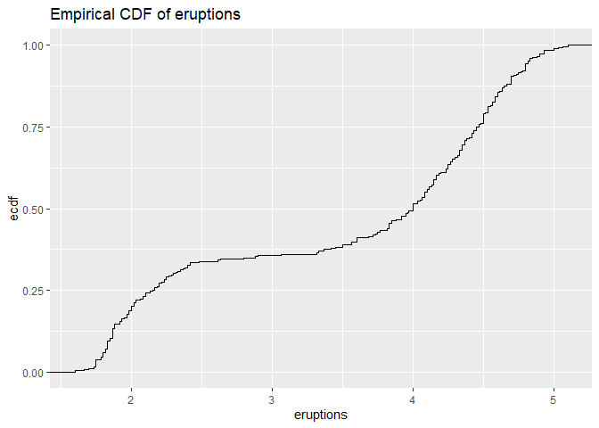

```r
a1<-ggplot(faithful,aes(eruptions))
a1+stat_ecdf() + ggtitle("Empirical CDF of eruptions")
```

## 2.5 Normal quantile plots

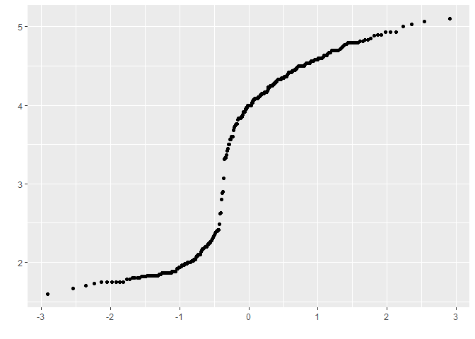

```r
qplot(sample=eruptions,data=faithful,geom="qq")
```

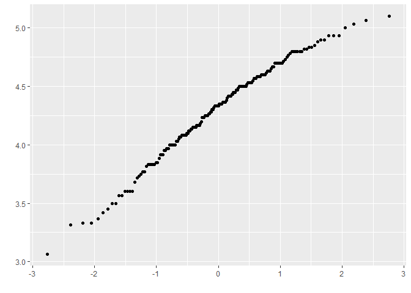

```r
qplot(sample=eruptions,data=subset(faithful,eruptions>3),geom="qq")
```

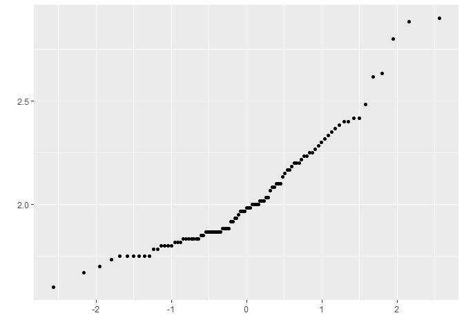

```r
qplot(sample=eruptions,data=subset(faithful,eruptions<=3),geom="qq")
```

```r
# ggplot(faithful,aes(sample=eruptions))+stat_qq()+ggtitle("Normal QQ plot of eruptions")
# ggplot(subset(faithful,eruptions>3),aes(sample=eruptions))+stat_qq()+ggtitle("Normal QQ plot of eruptions which are >3")#
# ggplot(subset(faithful,eruptions<=3),aes(sample=eruptions))+stat_qq()+ggtitle("Normal QQ plot of eruptions which are <=3")
```

## 2.6 Certain observations from the plots

1. Eruption times and the waiting times between successive eruptions exhibit highly oscillatory behavior, low followed by high and high followed by low.
2. Eruption times have a bimodal distribution.
3. Lower eruption times are followed by lower waiting times. Higher eruption times are followed by higher waiting times. This can be used to predict when the next geyser eruption will occur. For example, during a short eruption, less water and heat are used and so both are restored in shorter time. During longer eruptions, more time is needed to rebuild.

## 2.7 T-test and finding confidence intervals**

1. Performs a one sample t-test to test the hypothesis that the mean of waiting time $\mu = \mu_0$ and derives the 95% confidence interval for the mean parameter. Note the goal is more to find the confidence interval here.

```r
mean(faithful$waiting)
```

```
## [1] 70.89706
```

```r
faithful1 <- subset(faithful,faithful$eruptions <= 3)
faithful2 <- subset(faithful,faithful$eruptions > 3)


summary(faithful1$waiting)
```

```
##    Min. 1st Qu.  Median    Mean 3rd Qu.    Max.
##   43.00   50.00   54.00   54.49   59.00   71.00
```

```r
?t.test
str(faithful1)
```

```
## 'data.frame':    97 obs. of  2 variables:
##  $ eruptions: num  1.8 2.28 2.88 1.95 1.83 ...
##  $ waiting  : num  54 62 55 51 54 47 52 62 52 51 ...
```

```r
t.test(faithful1$waiting,mu=71)
```

```
##
##  One Sample t-test
##
## data:  faithful1$waiting
## t = -27.835, df = 96, p-value < 2.2e-16
## alternative hypothesis: true mean is not equal to 71
## 95 percent confidence interval:
##  53.31781 55.67189
## sample estimates:
## mean of x
##  54.49485
```

```r
t.test(faithful2$waiting,mu=71)
```

```
##
##  One Sample t-test
##
## data:  faithful2$waiting
## t = 19.837, df = 174, p-value < 2.2e-16
## alternative hypothesis: true mean is not equal to 71
## 95 percent confidence interval:
##  79.09425 80.88289
## sample estimates:
## mean of x
##  79.98857
```

```r
t.test(faithful2$waiting,mu=71,conf.level=.99)
```

```
##
##  One Sample t-test
##
## data:  faithful2$waiting
## t = 19.837, df = 174, p-value < 2.2e-16
## alternative hypothesis: true mean is not equal to 71
## 99 percent confidence interval:
##  78.80847 81.16867
## sample estimates:
## mean of x
##  79.98857
```

## 2.8 Two sample t-test

```r
t.test(faithful1$waiting,faithful2$waiting)
```

```
##
##  Welch Two Sample t-test
##
## data:  faithful1$waiting and faithful2$waiting
## t = -34.161, df = 202.71, p-value < 2.2e-16
## alternative hypothesis: true difference in means is not equal to 0
## 95 percent confidence interval:
##  -26.96519 -24.02226
## sample estimates:
## mean of x mean of y
##  54.49485  79.98857
```

2. With 95% confidence, if the eruption time < 3, the average waiting time is between 53.32 and 55.67.
3. With 95% confidence, if the eruption time >= 3, the average waiting time is between 79.10 and 80.88.
4. With 95% confidence, the difference between the average waiting time for the two categories is between -26.97 and -24.02.